# Code Sample: Pothole 311 Report Exploratory Data Analysis

Author

Jennifer Andre

Published

May 21, 2023

# Exploratory Data Analysis of Pothole Reports and Repairs in Washington, DC

Code sample located [here](https://github.com/jandre17/code-samples/tree/main/eda_potholes_R). (https://github.com/jandre17/code-samples/tree/main/eda_potholes_R)

Note: This code sample is contained within a Quarto document. [Quarto](https://quarto.org/) is a powerful scientific publishing system for documentation and reproducibility of data analyses.

## Introduction

Potholes can cause damage to vehicles and are a danger to drivers, bicyclists, and pedestrians alike. Fundamental city functions like pothole investigations and repairs help to keep streets safe and prevent interruptions to road travel.

Residents of Washington, DC can request pothole repairs via the [311 reporting process](https://311.dc.gov/citizen/home). The [District Department of Transportation (DDOT) website](https://ddot.dc.gov/service/pothole-repair) states “DDOT’s standard is to repair potholes within three business days (72 hours) of the time they are reported.”

### Purpose

The goal of this exploratory data analysis is to explore and summarize some prominent features of the 311 pothole reports data set. Two primary analysis questions guide this exploration:

1. How does the incidence of pothole repair requests in Washington, DC vary by geographic location or by time of year?
2. How timely are DDOT Pothole repairs, and are there disparities in wait times by Ward, month of report, or day of report? What are the most important predictors of on-time resolution of pothole investigation and repair?

### Data Sources

The primary data source used for this analysis is [311 City Service Requests in 2021](https://opendata.dc.gov/datasets/DCGIS::311-city-service-requests-in-2021/about), accessed via the [Open Data DC](https://opendata.dc.gov/) portal.

Supplemental data sources include 2017-2021 American Community Survey 5-year estimates (accessed via the `tidycensus` package) and geographic boundary data from the US Census Bureau (accessed via the `tigris` package).

## Setup

The code block below lists packages that are necessary to install and load for this analysis.

RStudio v2022.07 or later is required to edit and preview Quarto documents.

The `tidycensus` package can be used without an API key for a limited number of queries. To install an API key in your `.REnviron` file, run `census_api_key("[key]", install = TRUE)`.

```r
# load packages
library(sf)
library(tidyverse)
library(ggplot2)
library(ggthemes)
library(tigris)
library(knitr)
library(tidycensus)
library(tidymodels)
library(vip)

# set visualization theme
theme_set(theme_minimal())
```

## Prep Data

In this section, I will load, explore, and prepare the data sources for this analysis.

### 311 City Service Requests in 2021

These data are from the DC 311 service request center. The full data set includes all service requests for abandoned vehicles, bulk trash pickup, streetlight repairs, and more. For this analysis, I will investigate pothole reports only.

#### Access and Load

The `sf` package enables me to easily read `geojson` data from the Open Data DC API. I used the [API Explorer](https://opendata.dc.gov/datasets/DCGIS::311-city-service-requests-in-2021/api) to create a query URL that is restricted to pothole reports only (SERVICE CODE = S0301).

```r
# create query URL using Open Data DC API Explorer
# restricted to "SERVICE CODE" = "S0301" ("Pothole")
dc_url <- "https://maps2.dcgis.dc.gov/dcgis/rest/services/DCGIS_DATA/ServiceRequests/MapServer/12/query?where=SERVICECODE%20%3D%20'S0301'&outFields=*&outSR=4326&f=json"

# read data object from query URL and convert column names to lowercase
df_prep <- st_read(dc_url) %>%
  rename_with(tolower, everything())

# remove point geometry from this dataframe - not necessary for this analysis
st_geometry(df_prep) <- NULL
```

To verify that the API call worked as intended, I’ll check that all records have “S0301” in the `servicecode` field.

```r
# verify API result
stopifnot(df_prep$servicecode == "S0301")
```

#### Data Munging

Next, I explore the characteristics of the data set and determine some preparation steps for analysis.

The 311 potholes data set has 3,409 rows and 34 columns.

The simple summary below shows column names, class types, and some summary statistics. There are many variables in this dataset that I will not explore in this analysis, and I will remove these in a later step. This summary output also reveals to me that some of the fields I do intend to use are currently formatted in class types that will be difficult to work with (e.g., dates as strings), and I will need to adjust these.

```r
# summarize columns
kable(summary(df_prep))
```

|  | objectid | servicecode | servicecodedescription | servicetypecodedescription | organizationacronym | servicecallcount | adddate | resolutiondate | serviceduedate | serviceorderdate | inspectionflag | inspectiondate | inspectorname | serviceorderstatus | status_code | servicerequestid | priority | streetaddress | xcoord | ycoord | latitude | longitude | city | state | zipcode | maraddressrepositoryid | ward | details | gis_id | … |
| --- | --- | --- | --- | --- | --- | --- | --- | --- | --- | --- | --- | --- | --- | --- | --- | --- | --- | --- | --- | --- | --- | --- | --- | --- | --- | --- | --- | --- | --- | --- |
|  | Min. : 9591960 | Length:3409 | Length:3409 | Length:3409 | Length:3409 | Min. :1 | Length:3409 | Length:3409 | Length:3409 | Length:3409 | Length:3409 | Length:3409 | Length:3409 | Length:3409 | Length:3409 | Length:3409 | Length:3409 | Length:3409 | Min. :390376 | Min. :127421 | Min. :38.81 | Min. :-77.11 | Length:3409 | Length:3409 | Min. :20001 | Min. : 7 | Length:3409 | Length:3409 | Length:3409 | … |
|  | 1st Qu.: 9644317 | Class :character | Class :character | Class :character | Class :character | 1st Qu.:1 | Class :character | Class :character | Class :character | Class :character | Class :character | Class :character | Class :character | Class :character | Class :character | Class :character | Class :character | Class :character | 1st Qu.:396549 | 1st Qu.:135933 | 1st Qu.:38.89 | 1st Qu.:-77.04 | Class :character | Class :character | 1st Qu.:20007 | 1st Qu.:218344 | Class :character | Class :character | Class :character | … |
|  | Median : 9705982 | Mode :character | Mode :character | Mode :character | Mode :character | Median :1 | Mode :character | Mode :character | Mode :character | Mode :character | Mode :character | Mode :character | Mode :character | Mode :character | Mode :character | Mode :character | Mode :character | Mode :character | Median :398900 | Median :138507 | Median :38.91 | Median :-77.01 | Mode :character | Mode :character | Median :20012 | Median :267957 | Mode :character | Mode :character | Mode :character | … |
|  | Mean : 9740513 | NA | NA | NA | NA | Mean :1 | NA | NA | NA | NA | NA | NA | NA | NA | NA | NA | NA | NA | Mean :398762 | Mean :138225 | Mean :38.91 | Mean :-77.01 | NA | NA | Mean :20017 | Mean :385189 | NA | NA | NA | … |
|  | 3rd Qu.: 9819700 | NA | NA | NA | NA | 3rd Qu.:1 | NA | NA | NA | NA | NA | NA | NA | NA | NA | NA | NA | NA | 3rd Qu.:401184 | 3rd Qu.:140995 | 3rd Qu.:38.94 | 3rd Qu.:-76.99 | NA | NA | 3rd Qu.:20019 | 3rd Qu.:804539 | NA | NA | NA | … |
|  | Max. :10049445 | NA | NA | NA | NA | Max. :1 | NA | NA | NA | NA | NA | NA | NA | NA | NA | NA | NA | NA | Max. :407708 | Max. :147155 | Max. :38.99 | Max. :-76.91 | NA | NA | Max. :20591 | Max. :914193 | NA | NA | NA | … |
|  | NA | NA | NA | NA | NA | NA | NA | NA | NA | NA | NA | NA | NA | NA | NA | NA | NA | NA | NA | NA | NA | NA | NA | NA | NA’s :2 | NA | NA | NA | NA | … |

For example, I want to use the `adddate` (date and time of report), `resolutiondate` (date and time of service completion), and `serviceduedate` (repair due date - 3 business days after `adddate`) fields to examine pothole repair wait times. These are currently stored as character versions of date-times, which are not very useful (for example: 1609534924000).

I created the below function to parse these character dates into workable date-times. In a later step, I will apply this function, calculate the times between these dates (“wait time” and “overdue time”), and create factors indicating the month, week, and date of the 311 report.

```r
# function for cleaning character dates
# input: character date field
# output: datetime field
clean_date <- function(date) {

  strip <- sub("0{3}$", "", date) # remove trailing zeroes
  num <- as.numeric(strip) # convert character to numeric
  datetime <- as_datetime(num) # convert numeric to datetime

  return(datetime)
}
```

In this analysis, I will explore differences in reports and completion times by Ward. The table below shows a simple tabulation of reports by Ward. In a later step, I will format the Ward variable as a factor for later use.

```r
# count of pothole reports by Ward
kable(table(df_prep$ward),
      col.names = c("Ward", "311 Pothole Reports"))
```

| Ward | 311 Pothole Reports |
| --- | --- |
| 1 | 335 |
| 2 | 397 |
| 3 | 524 |
| 4 | 414 |
| 5 | 545 |
| 6 | 355 |
| 7 | 427 |
| 8 | 412 |

```r
# count of pothole reports by priority type
kable(table(df_prep$priority),
      col.names = c("Priority", "311 Pothole Reports"),
      format.args = list(big.mark = ","))
```

| Priority | 311 Pothole Reports |
| --- | --- |
| High | 3 |
| Low | 1 |
| Standard | 3,403 |
| Urgent | 2 |

Finally, I will check the service order status field. The table below shows that most records are `Closed`. I only want to explore 311 reports that have been completed in this analysis, so I will filter to these `Closed` records in a later step.

```r
# count of pothole reports by service order status
kable(table(df_prep$serviceorderstatus),
      col.names = c("Service Order Status", "311 Pothole Reports"),
      format.args = list(big.mark = ","))
```

| Service Order Status | 311 Pothole Reports |
| --- | --- |
| Canceled | 4 |
| Closed | 3,393 |
| In-Progress | 8 |
| Open | 1 |
| Voided | 3 |

#### Create Analysis Data

In this section, I create an analysis dataframe with the modifications I determined in the previous exploratory steps. I also create a few new fields that I will explore as predictors in a later analysis.

```r
df <- df_prep %>%

  # first, use mutate to implement wrangling steps
  mutate(

    # apply clean_date function to date fields
    across(c(adddate, resolutiondate, serviceduedate), clean_date),

    # create date version of report date (without time stamp),
    adddate_date = as.Date(adddate),

    # create on-time boolean
    on_time_completion = resolutiondate <= serviceduedate,

    # calculate number of days between resolution and due date (overdue time)
    overdue_time = if_else(resolutiondate > serviceduedate,
                           difftime(resolutiondate, serviceduedate, units = "days"),
                           NA),

    # calculate number of days between resolution and date of report (wait time)
    wait_time = difftime(resolutiondate, adddate, units = "days"),

    # create factor variables for the month, week, and day of report
    report_month = month(adddate, label = TRUE),
    report_week = as.factor(week(adddate)),
    report_day = wday(adddate, label = TRUE),

    # format ward as a factor variable
    ward = as.factor(ward)

    ) %>%

  # next, filter to keep only "Closed" records
  filter(serviceorderstatus == "Closed") %>%

  # then, add monthly, weekly, and daily report volume to use as predictors in later analyses
  add_count(report_month, name = "tot_report_month") %>%
  add_count(report_week, name = "tot_report_week") %>%
  add_count(adddate_date, name = "tot_report_day") %>%

  # as a final step, remove some unused fields for the sake of clarity
  select(-c(servicecodedescription, servicetypecodedescription,
            serviceorderdate, inspectionflag, inspectiondate, inspectorname,
            status_code, servicerequestid, organizationacronym, servicecallcount,
            streetaddress, xcoord, ycoord, latitude, longitude, city, state,
            maraddressrepositoryid, details, gis_id, globalid,
            creator, created, editor, edited))
```

### American Community Survey Data

Next, I access and prepare Ward-level population counts from the Census Bureau American Community Survey 2017-2021 5-year estimates. These will be used to standardize Ward-level counts of 311 reports.

```r
# use tidycensus to query API
# Census API key is saved in .REnviron file
# see: https://search.r-project.org/CRAN/refmans/tidycensus/html/census_api_key.html
dc_acs_prep <- get_acs(geography = "state legislative district (upper chamber)",
                       variables = c(population = "B01001_001"),
                       state = "DC",
                       year = 2021)

# create ward as a factor, keep ward and population for later use
dc_acs <- dc_acs_prep %>%
  mutate(ward = as.factor(substring(sub("^Ward ", "", NAME), 1, 1))) %>%
  rename(population = estimate) %>%
  select(ward, population)
```

### Census Geographic Data

Finally, I access shapefiles of DC Wards from Census Bureau data using the `tigris` package.

```r
# access boundaries of DC Wards
wards_prep <- state_legislative_districts(
  state = "DC",
  house = "upper",
  cb = FALSE,
  year = 2021)

# create ward factor
wards <- wards_prep %>%
  mutate(ward =  as.factor(substring(sub("^Ward ", "", NAMELSAD), 1, 1)))
```

## Analysis

In the following sections, I will explore my two primary analysis questions.

### Q1: Incidence of 311 Pothole Reports

How does the incidence of pothole repair requests in Washington, DC vary by geographic location or by time of year?

#### A. Incidence by Geographic Location

Earlier, I tabulated counts of 311 Pothole reports by Ward. I now want to visualize these report counts on a map of DC Wards. I also want to account for differences in populations between wards and standardize the reports counts by population.

Note: This is an imperfect way to standardize report volumes. A recommendation for future work is to standardize Ward-level report counts by the number of vehicles in a Ward, a measure of road usage, and/or some measure of natural susceptibility to potholes.

First, I’ll create a dataframe of reports and population-standardized reports by Ward, and I’ll join this with my spatial data.

```r
ward_reports <- df %>%

  # count reports by ward
  group_by(ward) %>%
  summarize(reports = n()) %>%

  # join ACS population data and create a standardized reports measure
  left_join(dc_acs, by = "ward") %>%
  mutate(reports_per1k = reports / (population / 1000))

# join report counts and standardized counts to the ward boundaries object
ward_reports_geo <- wards %>%
  left_join(ward_reports, by = "ward")
```

```r
# counts of reports and standardized reports by Ward
kable(ward_reports,
      col.names = c("Ward",
                    "311 Pothole Reports",
                    "Population",
                    "Reports per 1K Population"),
      format.args = list(big.mark = ",", digits = 3))
```

| Ward | 311 Pothole Reports | Population | Reports per 1K Population |
| --- | --- | --- | --- |
| 1 | 333 | 82,404 | 4.04 |
| 2 | 391 | 76,492 | 5.11 |
| 3 | 523 | 82,450 | 6.34 |
| 4 | 414 | 86,085 | 4.81 |
| 5 | 543 | 88,948 | 6.10 |
| 6 | 355 | 102,233 | 3.47 |
| 7 | 425 | 81,270 | 5.23 |
| 8 | 409 | 83,272 | 4.91 |

Next, I will create a map plot function and apply it to the report counts and standardized report counts.

```r
# prepare basic map plot function
# input: fill variable
# output: map ggplot object
map_dc <- function(fillvar){

  ggplot(data = ward_reports_geo) +
    geom_sf(aes(fill = !!sym(fillvar))) +
    geom_sf_label(aes(label = NAMELSAD),
                  size = 2.5) +
    theme_map()

}
```

```r
# create map for report counts
reports_map <- map_dc("reports") +
  scale_fill_continuous(trans = "reverse",
                        name = "311 Pothole Reports") +
  labs(title = "Incidence of Reports (Total) by Ward")

# create map for standardized report counts
standardized_map <- map_dc("reports_per1k") +
  scale_fill_continuous(trans = "reverse",
                        name = "311 Pothole Reports\nper 1K Population") +
  labs(title = "Incidence of Reports (Standardized) by Ward")
```

The resulting choropleth maps are displayed below. The distributions of reports and standardized reports by Ward are very similar, but there are some differences. For example, Ward 2 appears to have a higher report incidence (in relative terms) when standardizing by population.

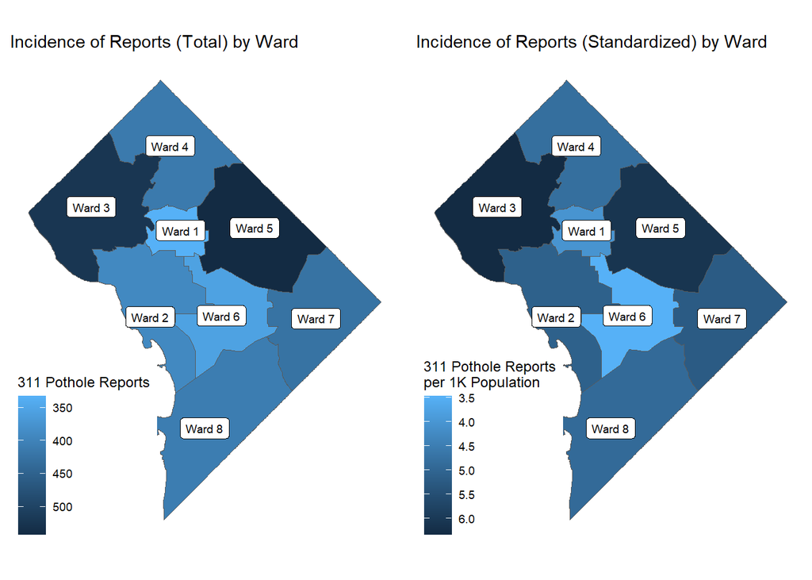

```r
# display maps side-by-side
grid.arrange(reports_map, standardized_map, nrow = 1)
```

Overall, the distributions of report incidence and standardized report incidence by Ward are very similar. Looking comparatively at the Wards, Wards 3 and 5 have the highest incidence of pothole reports, while Wards 1 and 6 have the lowest.

#### B. Incidence by Time of Year

The plot below shows the number of pothole reports by day throughout 2021. The incidence of reports is much higher in March and April compared to the rest of the year. It does not seem surprising that these reports spike in spring, when potholes are more likely to appear following the freezing and wet winter months.

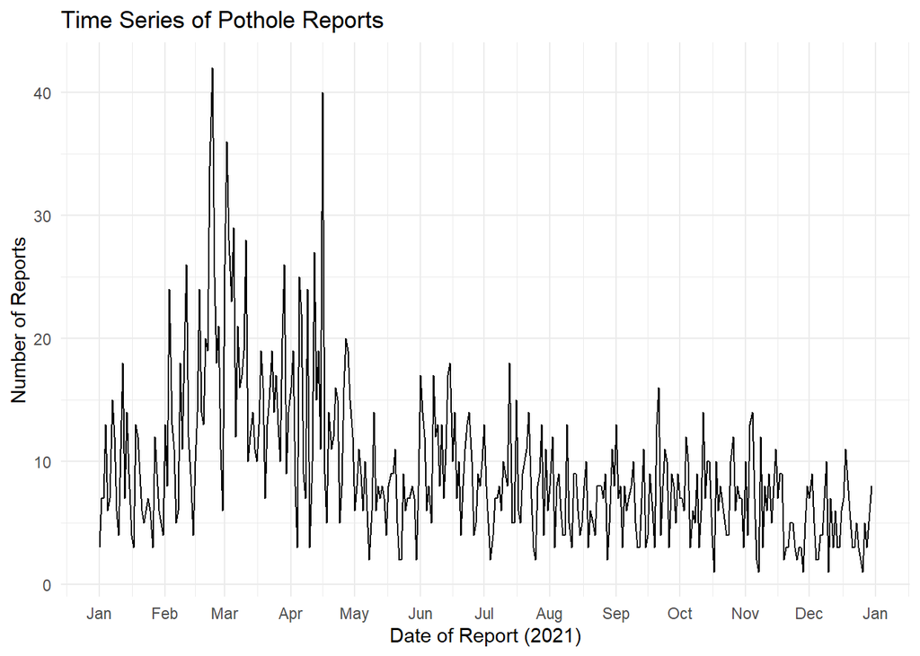

```r
# filter dataframe to daily counts of reports and plot time series
df %>%
  distinct(adddate_date, tot_report_day) %>%
  ggplot(aes(x = adddate_date, y = tot_report_day)) +
    geom_line() +
    labs(title = "Time Series of Pothole Reports",
         x = "Date of Report (2021)",
         y = "Number of Reports") +
  scale_x_date(date_breaks = "1 month",
               date_labels = "%b")
```

### Q2: Timeliness of Repairs and Disparities in Wait Times

How timely are DDOT Pothole repairs, and are there disparities in wait times by Ward, month of report, or day of report? What are the most important predictors of on-time resolution of pothole investigation and repair?

#### A. Overall Timeliness and Wait Times

Overall, 2,658 pothole reports are resolved on or before the service due date. This means that 78% of reports are resolved on-time.

The median wait time is 2.17 days, well below the 3 business day expected wait time. The average wait time (including weekends) is 3.3 days. It is not surprising that the mean is higher, given that those reporting a pothole on a Thursday or Friday will automatically need to wait longer for a resolution. A recommendation for future work is to remove weekends and holidays from these wait times.

The median overdue time (i.e., total time beyond service due date) is 1.89 days, well below the 3 business day expected wait time. The average overdue time (including weekends) is 3.83 days.

Next, I’ll take a closer look at the distributions of these wait times and overdue times.

```r
# prepare data for plot by pivoting time types to longer and preparing variable types
bp_prep <- df %>%
  select(objectid, wait_time, overdue_time) %>%
  pivot_longer(!objectid,
               names_to = "type",
               values_to = "time") %>%
  filter(is.na(time) == FALSE) %>%
  mutate(type = as.factor(type),
         time = as.numeric(time))
```

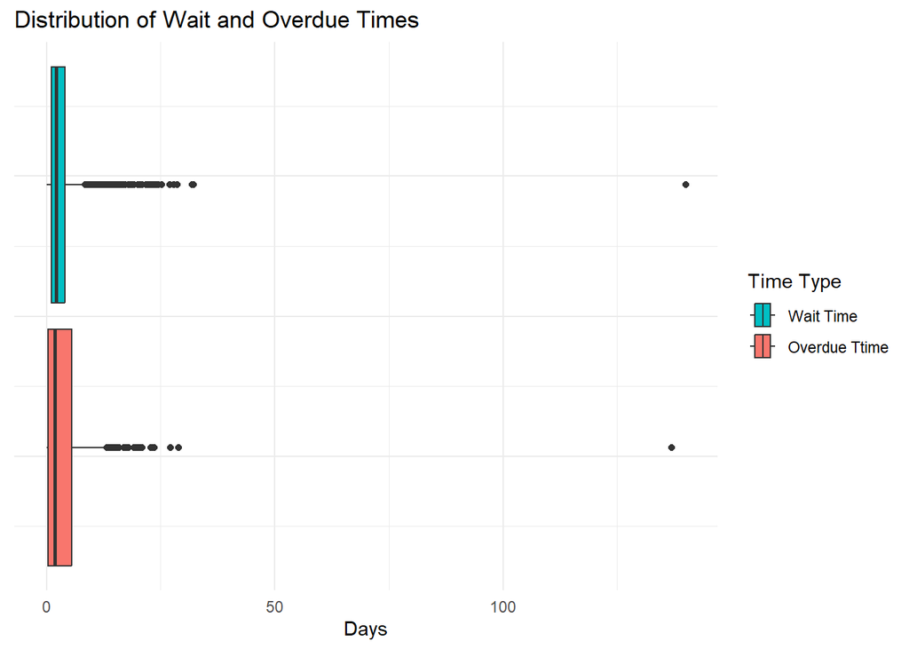

```r
# plot side-by-side boxplots
bp_prep %>%
  ggplot(aes(x = time, fill = type)) +
    geom_boxplot() +
    labs(title = "Distribution of Wait and Overdue Times",
         x = "Days") +
     scale_fill_discrete(name = "Time Type",
                         breaks = c("wait_time", "overdue_time"),
                         labels = c("Wait Time", "Overdue Ttime")) +
    theme(axis.ticks.y = element_blank(),
          axis.text.y = element_blank())
```

These distributions are difficult to see because of one large outlier report. I will remove that observation to improve the plot visually.

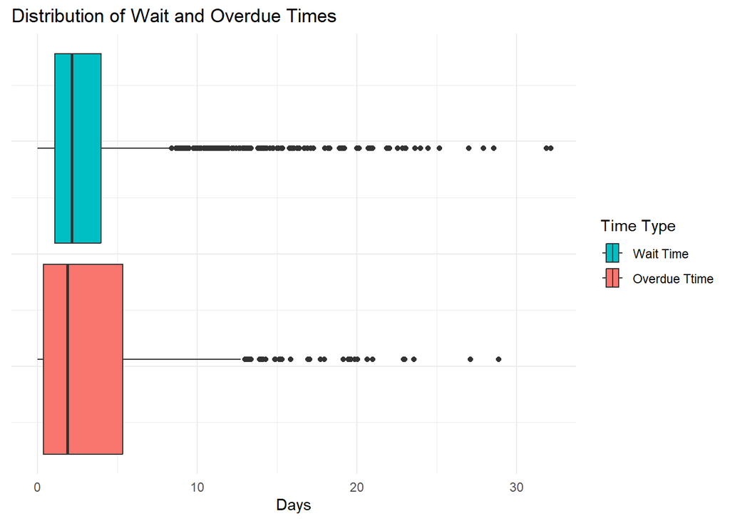

```r
# remove outliers, and plot
bp_prep %>%
  filter((as.numeric(time) < 100)) %>%
  ggplot(aes(x = time, fill = type)) +
    geom_boxplot() +
    labs(title = "Distribution of Wait and Overdue Times",
         x = "Days") +
     scale_fill_discrete(name = "Time Type",
                         breaks = c("wait_time", "overdue_time"),
                         labels = c("Wait Time", "Overdue Ttime")) +
    theme(axis.ticks.y = element_blank(),
          axis.text.y = element_blank())
```

Overall, the majority of pothole repairs are completed on time. However, the distributions of wait times and overdue times show that some reports take much longer than expected to be resolved, with some reports being resolved nearly one month after initial report.

#### B. Disparities in On-Time Performance, Wait Times, and Overdue Times

Are there disparities in on time performance, wait times, and overdue times? Is on-time performance or speed of resolution correlated with Ward, month of report, or day of report?

To explore this, I will take a closer look at mean performance across Wards, month of pothole report, and day of pothole report. The following bar charts show mean values with bootstrapped 95% confidence intervals. These confidence intervals help to determine if differences are statistically significant. I use bootstrapping here to make no assumptions about the normality of underlying distributions.

A recommendation for future work is to compare medians, which are less influenced by extreme values and may be more reflective of a typical wait time.

```r
# first, create a function to plot bars and error bars with xvar and yvar inputs
# inputs: x variable name (group), y variable name (metric)
# output: bar chart with 95% bootstrap confidence intervals
plot_disp <- function(xvar, yvar) {

  ggplot(df, aes(x = !!sym(xvar), y = as.numeric(!!sym(yvar)))) +
    geom_bar(stat = "summary", fun = "mean", na.rm = TRUE) +
    stat_summary(fun.data = "mean_cl_boot", geom = "errorbar", na.rm = TRUE) +
    scale_y_continuous(expand = expansion(mult = c(0, 0.1))) +
    labs(x = str_to_sentence(gsub("_", " ", xvar)),
         y = str_to_sentence(gsub("_", " ", yvar)),
         title = paste0("Average ", gsub("_", " ", yvar), " by ", gsub("_", " ", xvar)))

}

# create vectors of x variables to iterate over
xvars <- c("ward", "report_month", "report_day")
```

First, I will take a closer look at disparities in on-time performance rates by Ward, month of report, and day of report.

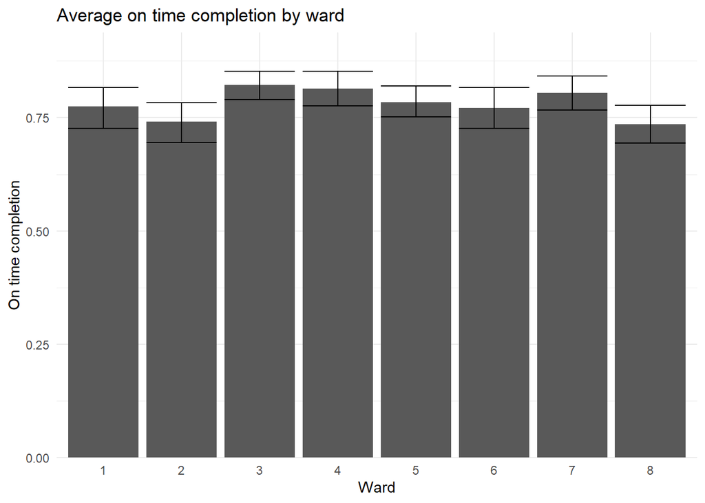

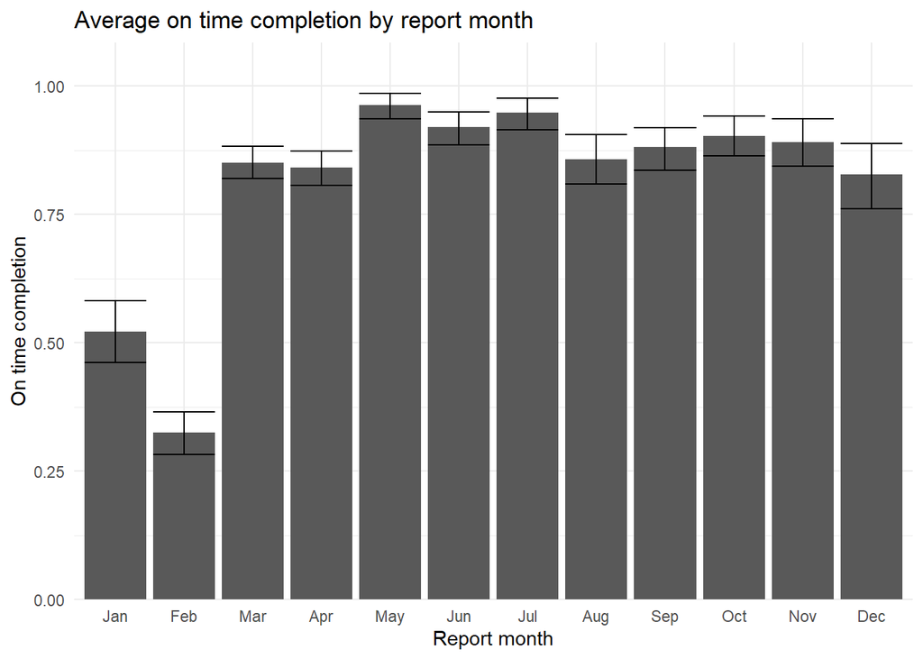

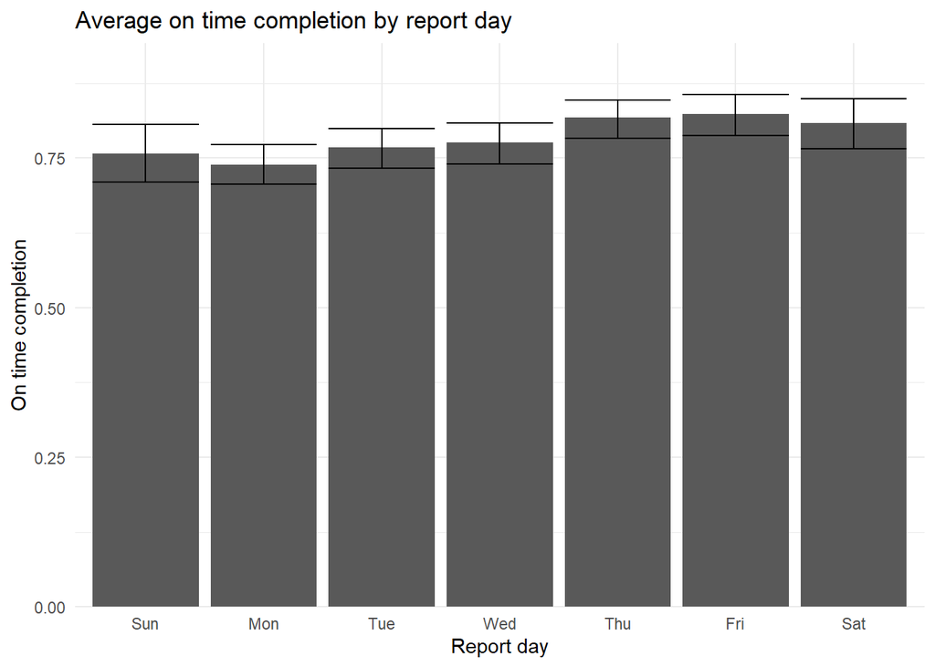

```r
# apply plotting function across xvars, using on-time completion metric
map(xvars, plot_disp, yvar = "on_time_completion")
```

Key takeaways:

- By Ward: On-time performance is pretty comparable across Wards, with only small mean differences.
- By month of report: On-time performance is significantly lower in January and February than in the other months of the year, which may indicate that poor weather conditions cause delays in repairs. On-time performance improves dramatically in March and April, though still remains a bit lower than other months. The time series plot earlier showed that March and April are the months with the most reports, and it seems that DDOT might have a hard time keeping up with them.
- By day of report: On-time performance is pretty comparable across day of week on which a report is made, with only small mean differences. Note: Recall that this on-time performance only considers business days. Potholes reported on Thursdays and Fridays may take more total days to repair due to the weekend, but will still be considered on time if resolved within 3 business days.

Next, I will take a closer look at disparities in mean wait time by Ward, month of report, and day of report. Wait time is not an ideal measure here because it includes weekends and holidays, which are days that DDOT does not count in repair time frames.

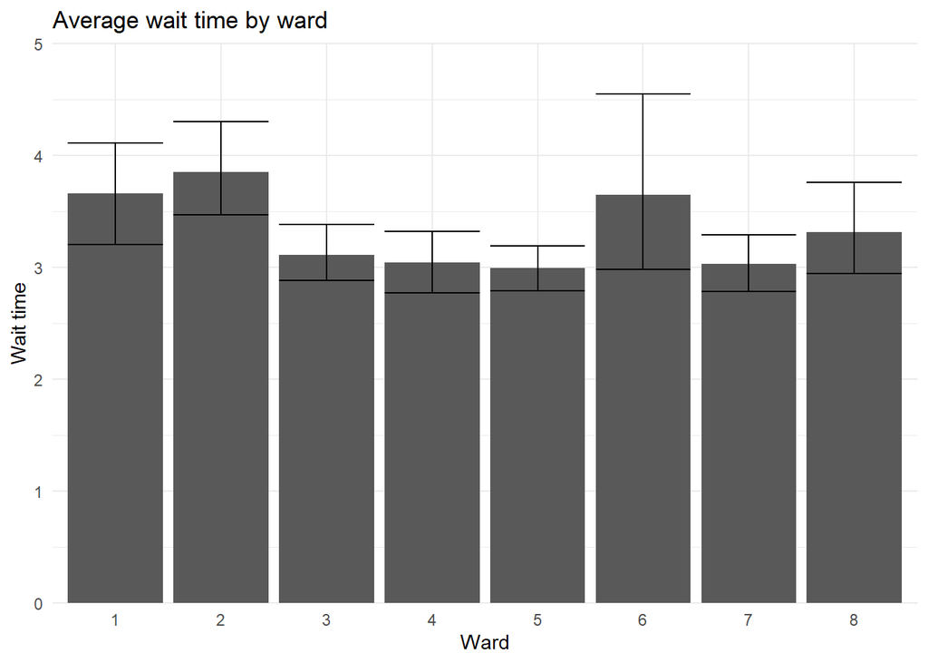

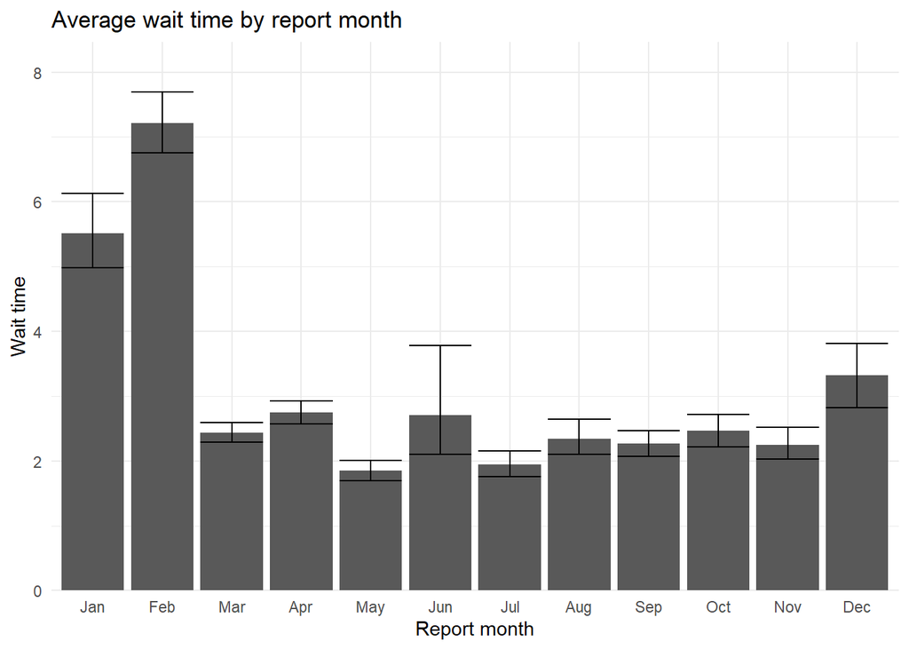

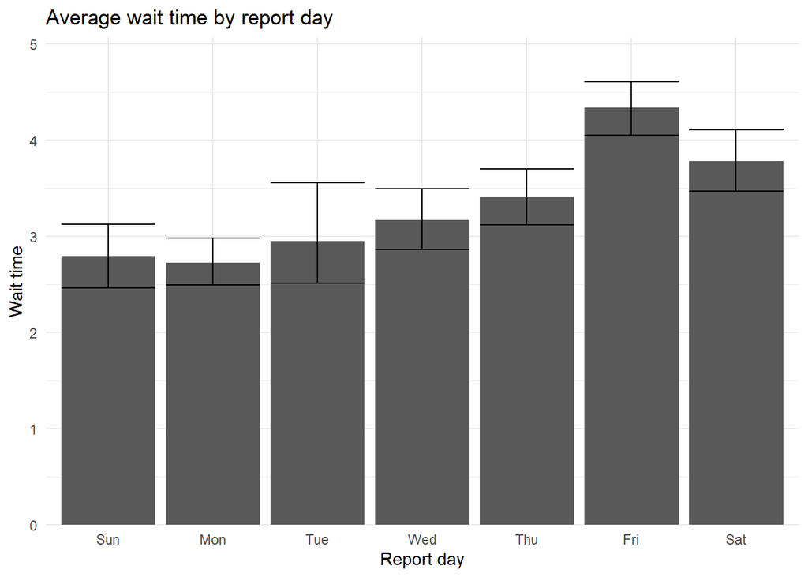

```r
# apply plotting function across xvars, using wait time metric
map(xvars, plot_disp, yvar = "wait_time")
```

Finally, I will take a closer look at disparities in mean overdue time by Ward, month of report, and day of report. This measure captures the overdue time between a service due date and the resolution date for repairs not completed on time. There is a lot more uncertainty in these estimates because there are fewer observations (only including those reports that were not resolved on time).

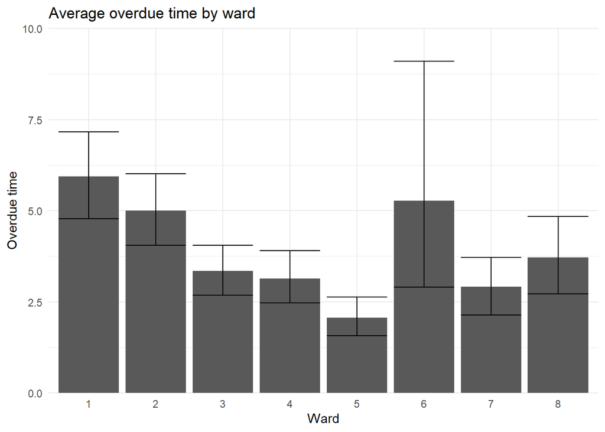

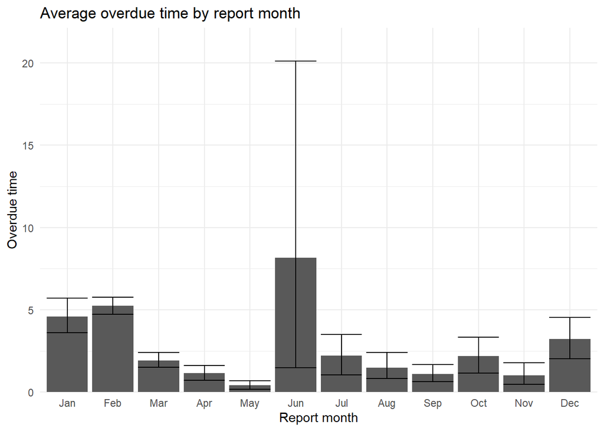

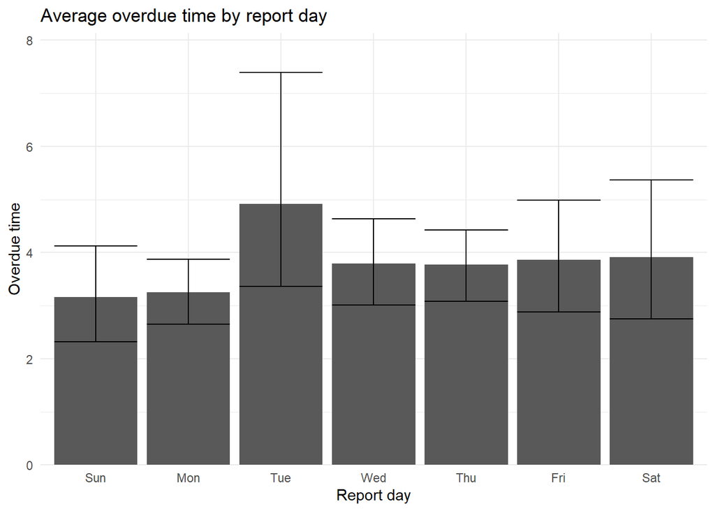

```r
# apply plotting function across xvars, using overdue time metric
map(xvars, plot_disp, yvar = "overdue_time")
```

There is one key overall takeaway from these plots. While there are some clear disparities in overdue time by Ward and by month of report, I think a likely explanation here is that the complexity of some cases and/or external factors may impacting resolution times. These are pothole reports that are taking an exceptionally long time to resolve, and it may be that the reasons are idiosyncratic. Maybe special materials were on back order, key personnel were unavailable, road conditions made the repair unsafe, or even a data entry/tracking error occurred. In any case, it seems unreasonable to place too much emphasis on these disparities in overdue time by ward without more information.

#### C. Predictors of On-Time Performance

Finally, I’ll use predictive modeling techniques to investigate on-time performance in a more comprehensive way, taking into account the various factors explored in this analysis.

Below, I build a classification model that predicts whether or not a pothole report is resolved on time based on the following predictors:

- Ward
- Day of the week that report is made
- Month that report is made
- Total reports made on the day of report
- Total reports made in the week of report

```r
# prepare modeling dataframe and create factor indicator for outcome (on-time completion)
df_pred <- df %>%
  select(on_time_completion, report_day, report_month, tot_report_day, tot_report_week, ward) %>%
  mutate(on_time_completion = as.factor(as.numeric(on_time_completion)))
```

```r
# set randomization seed for reproducibility.
set.seed(111)

# prepare tidymodels recipe, converting factor variables to series of dummies as needed
rec <- recipe(on_time_completion ~ ., data = df_pred) %>%
  step_dummy(ward, report_day, report_month)

# prepare random forest classification model using ranger engine
# set impurity method for feature importance
rf_mod <- rand_forest(mode = "classification") %>%
  set_engine("ranger", importance = "impurity")

# add model and recipe to workflow
wkf <- workflow() %>%
  add_model(rf_mod) %>%
  add_recipe(rec)
```

The top 10 features for predicting on-time performance are shown in the following plot.

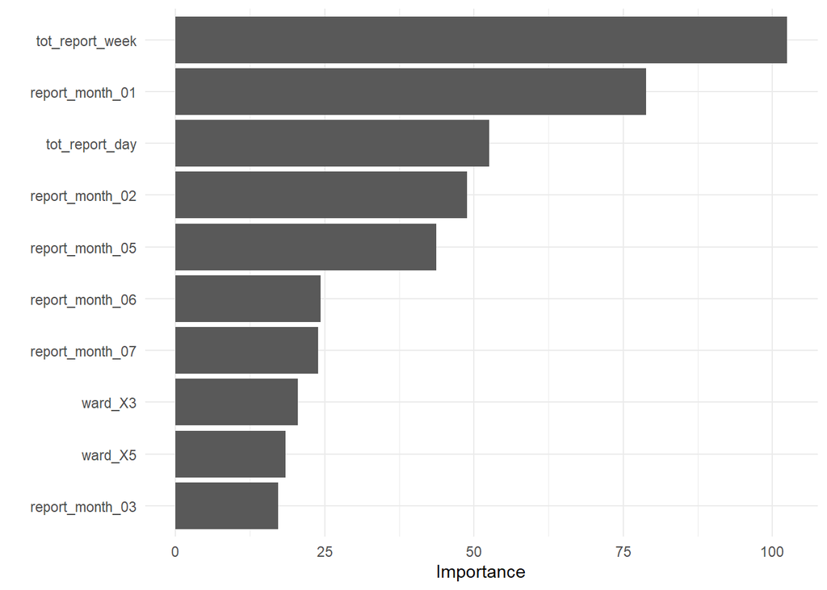

```r
# fit workflow to modeling dataframe
# extract and plot top feature importances and plot
wkf %>%
  fit(df_pred) %>%
  extract_fit_parsnip() %>%
  vip(num_features = 10)
```

The total number of reports made in the week of the report and on the same day of the report are among the most important predictive features (`tot_report_week` and `tot_report_day`). This aligns with the descriptive findings in this analysis, which highlighted a correlation between on-time performance and number of reports - in general, on-time performance was lower in the busiest reporting months. Similarly, reports being made in January and February are also among the most important features in the classification model (`report_month_01` and `report_month_02`).

Overall, the top 7 most important features have to do with reporting volumes or month of report. Ward features are of lower feature importance. These findings are consistent with earlier descriptive results.

## Limitations

One key limitation of this analysis is the limited information available. The 311 reporting database only includes information about the location and timing of a given pothole report. Therefore, the findings presented here are limited in utility. This exploratory analysis would be improved with more information about the pothole report. For example, pothole size (i.e., depth or diameter) and location (i.e., middle of road vs. side of road) are likely very important factors influencing on-time resolution because very large potholes in the middle of roads are likely prioritized. The 311 database does include a `priority` field but, as explored earlier, there are only a handful of reports not considered “Standard”.

Further, this analysis could be improved with some additional external information. For example, I would be interested to include some external data on weather conditions in this analysis because poor weather is likely positively correlated with the incidence of pothole reports as well as longer resolution wait times.

Finally, one potential problem with this analysis is that there could be “duplicates”, or multiple reports that refer to the same pothole. In other words, it seems likely that multiple residents could submit a 311 request for the same pothole on the same day or in the same week. This would create some bias in my results because these “duplicate” records would seemingly be resolved much more quickly than might otherwise be expected, since they actually refer to the same pothole. Closer investigation into the address field could shed light on this possibility.

## Conclusions

Overall, DDOT resolves about 3 in 4 pothole reports within 3 business days. However, on-time performance and wait times vary significantly over the course of the year, with much lower on-time performance in the winter months of January and February. There is little evidence of disparities in on-time performance by Ward, and many differences in overdue time can likely be explained by the idiosyncrasies of specific pothole repairs.

Finally, simple predictive modeling shows that the most important predictors of pothole resolution on-time performance are contemporaneous report volumes and month of report. DDOT has relatively poor performance resolving the pothole reports it receives during the winter and during particularly busy reporting times in the spring, and might consider taking proactive actions to reallocate resources to respond more quickly and efficiently during these times.